# ゲームハード週販レポート (2025.11.16)

国内ゲームハード週販レポート (2025-11-16)

- ハードウェアの販売データはファミ通の調査結果を基にしています。
- 一部のデータは処理上の都合により、週次値に調整しています。
- 過去の週販レポート

## 直近4週間のハード売り上げ／累計推移

Switch2の販売台数は先週の9万台からさらに増えて10万台。 最近は「店頭でSwitch2を見かけた、買えた」報告もXでよく見るので、 エアライダー出荷増で次週も期待できます。

Switchは安定してますが、初めてのおとなしい年末商戦とも言えます。

PS5はDE値下げ直前週なので減ってはいるのですが、買い控えの影響が意外と小さいです。 PS5 DE日本語版を求める人が多いなら、買い控えの影響が大きく出そうなものなのですが... 来週に注目です。

| 集計日 | ハード | 販売台数 | 累計台数 |
| --- | --- | --- | --- |
| 2025-10-26 | Nintendo Switch2 | 65,434 | 2,468,021 |
|  | Nintendo Switch | 25,109 | 36,124,524 |
|  | PlayStation5 | 10,503 | 7,121,667 |
|  | Xbox Series X\|S | 991 | 686,768 |
|  | PlayStation4 | 15 | 9,490,908 |
| 2025-11-02 | Nintendo Switch2 | 83,825 | 2,551,846 |
|  | Nintendo Switch | 26,708 | 36,151,232 |
|  | PlayStation5 | 7,537 | 7,129,204 |
|  | Xbox Series X\|S | 309 | 687,077 |
|  | PlayStation4 | 18 | 9,490,926 |
| 2025-11-09 | Nintendo Switch2 | 90,410 | 2,642,256 |
|  | Nintendo Switch | 23,877 | 36,175,109 |
|  | PlayStation5 | 7,691 | 7,136,895 |
|  | Xbox Series X\|S | 487 | 687,564 |
|  | PlayStation4 | 16 | 9,490,942 |
| 2025-11-16 | Nintendo Switch2 | 101,549 | 2,743,805 |
|  | Nintendo Switch | 22,736 | 36,197,845 |
|  | PlayStation5 | 5,855 | 7,142,750 |
|  | Xbox Series X\|S | 574 | 688,138 |
|  | PlayStation4 | 15 | 9,490,957 |

現時点の年間PS販売台数 724,741台、2020年の記録797,797台を超えるまで、あと73,057台

## 2025年の週販推移

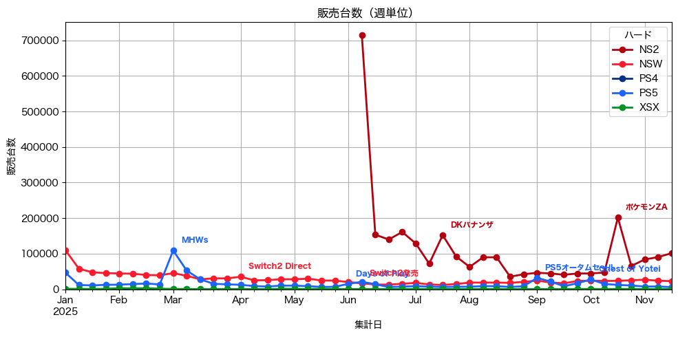

### 2025年の週販推移(拡大）

Switch2の年末商戦出荷が順調に伸びています。このまま年末まで増え続けるのか、10万ラインで推移するのか。

PS5については11月23日集計以降のPS5 DE(日本語版)の動き次第。

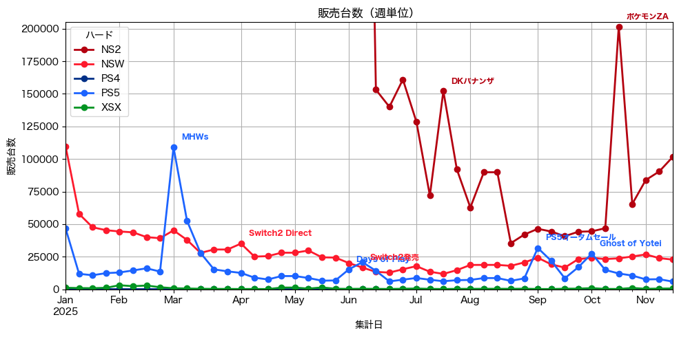

## 2025年の月間販売推移

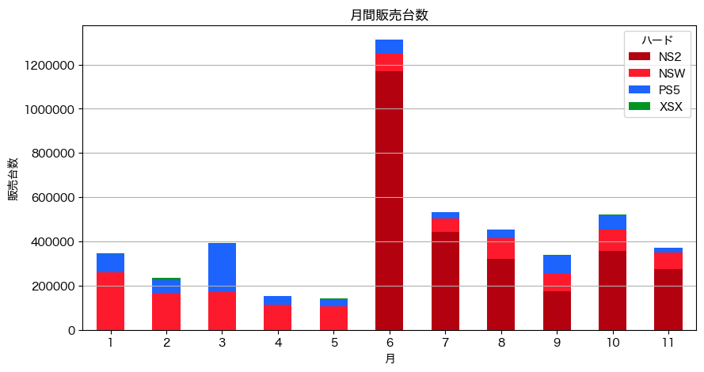

11月はあと2回集計を残しているので、Switch2は10月を超えるのは確実です。 Switchも10月を若干上回りそうです。

| hw month | NS2 | NSW | PS5 | XSX |
| --- | --- | --- | --- | --- |
| 1 | 0 | 260,447 | 81,587 | 3,861 |
| 2 | 0 | 167,188 | 56,886 | 9,751 |
| 3 | 0 | 171,921 | 218,300 | 2,081 |
| 4 | 0 | 113,513 | 38,983 | 1,710 |
| 5 | 0 | 106,506 | 32,001 | 3,467 |
| 6 | 1,169,684 | 78,097 | 63,516 | 1,400 |
| 7 | 444,706 | 57,532 | 28,959 | 1,197 |
| 8 | 319,690 | 94,517 | 39,004 | 1,599 |
| 9 | 175,542 | 82,946 | 78,693 | 1,121 |
| 10 | 358,399 | 96,080 | 64,732 | 2,253 |
| 11 | 275,784 | 73,321 | 21,083 | 1,370 |

### Nintendo Switchの月間販売台数： 2023,2024年との比較

Switch2大量出荷にも関わらずSwitchの販売台数は安定しています。 11月の販売台数は10月を若干上回ると思われます。

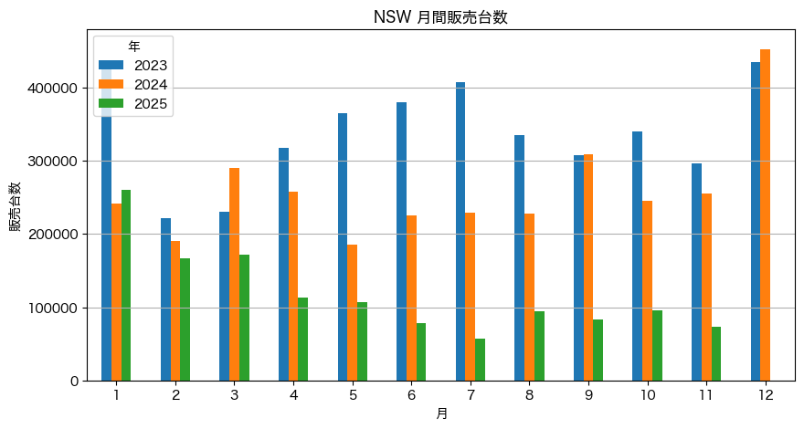

### PlayStation 5の月間販売台数： 2023, 2024年との比較

11月の前年比としては、現時点では悲惨な状況です。 11月21日のDE値下げまでは辛抱です。その後の跳ね上がりに期待しましょう。

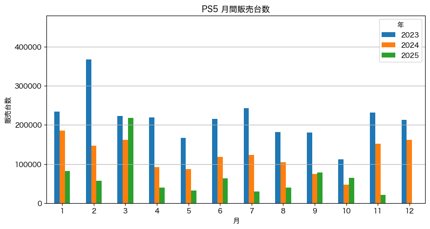

## 累計販売推移

Switchの累計3600万台が多過ぎて、Switchに合わせたスケールだと他機種の状況が全然わからないですね。

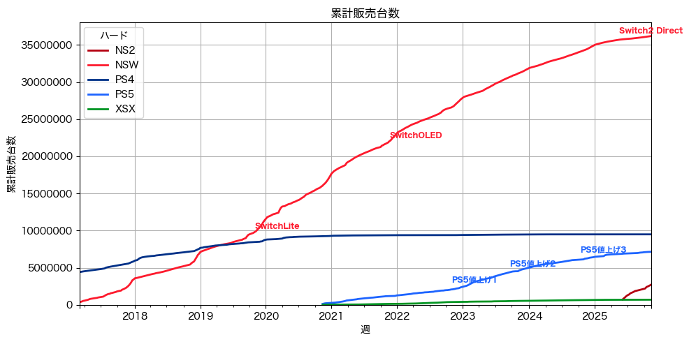

### 累計販売台数差

#### Switch vs PS4 & Switch2 vs PS5

Switch,Switch2がPS4,PS5にどのように追いついたか（追いつくか）を可視化しています。

SwitchとPS4は436万台差からスタートし約2年と2ヶ月(112週間)でPS4に追いつきました。 途中、PS4はMHWで盛り返し差が拡大した事もありますが、2回の年末商戦で大幅に差が縮まりました。

Switch2とPS5は686万台差からスタートしています。PS5はPS4よりも200万台以上多い有利な状態でライバル機種のロンチを迎えました。 Switch2はロンチ週に一気に70万台差を縮め、その後もSwitchに比べハイペースでPS5に接近しています。 年末商戦の大量出荷で一気に縮めるか、PS5 DEの値下げでPS5が踏ん張るのか、この年末の見どころです。

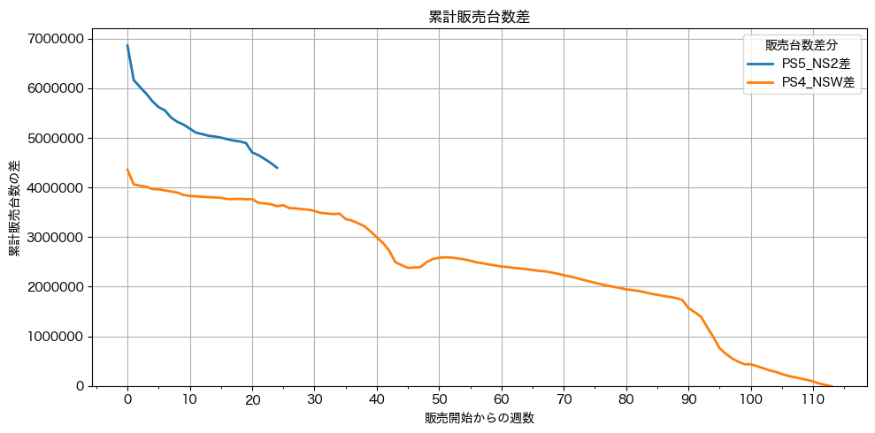

#### PS5 vs Switch

公平のためにPS5とSwitchの差も可視化しました。 PS5ロンチ時の差は1590万台。その後PS5とSwitchの間の差はほぼ拡大の一途。現在は2900万台差に広がっています。

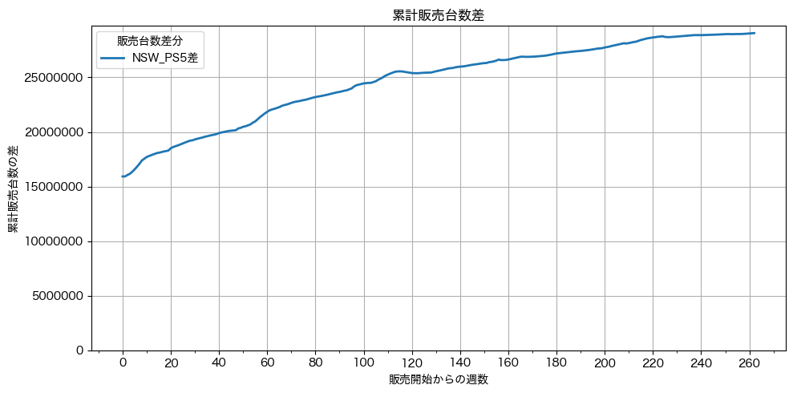

### PS5 vs PS4

PS5 DEの値下げでSwitch2対抗とか言われますが、私の考えではPS4対抗です。 PS4国内累計949万台に比べ、PS5は累計710万台。まだ240万台の普及余地が残っているはずです。 これを確実に獲ることがPS5DE日本語版のミッションでしょう。

というわけで、PS5とPS4の累計比較です。 最新状況の260週間経過時点では、PS5はPS4よりも70万台少ない状況です。 これが広がるのか縮まるのか、要注目です。

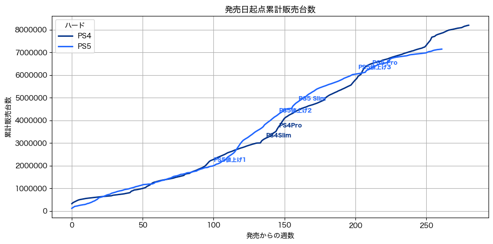

## Switch2初動状況

Switch2の累計グラフの傾きが年末商戦で上昇しつつあります。春までにGBAをキャッチアップするような動きになるかどうか。

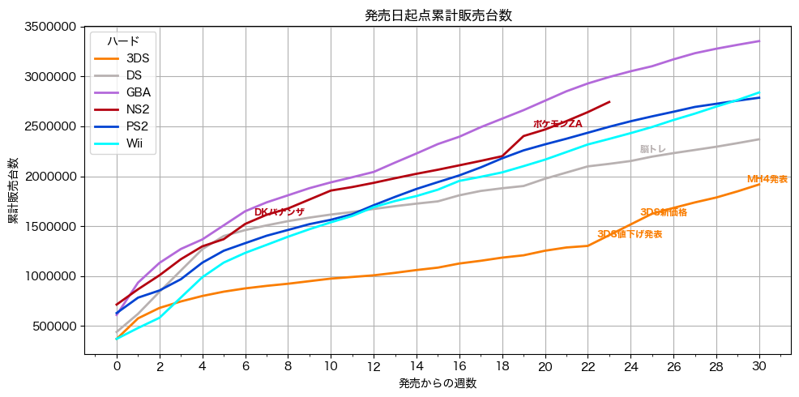

| ハード | 週数 | 販売数 |
| --- | --- | --- |
| GBA | 23 | 2,993,886 |
| NS2 | 23 | 2,743,805 |
| PS2 | 23 | 2,495,627 |
| Wii | 23 | 2,374,156 |
| DS | 23 | 2,124,349 |
| 3DS | 23 | 1,410,214 |

## 年単位の状況

全機種合わせた年毎のハード販売の状況です。

2025年の販売台数が480万台に到達し、2024年に続き2015年を超えました。来週には2016年の487万台を超えるのは確実です。 2018年、2019年の590万台の水準到達は難しいと思われます。

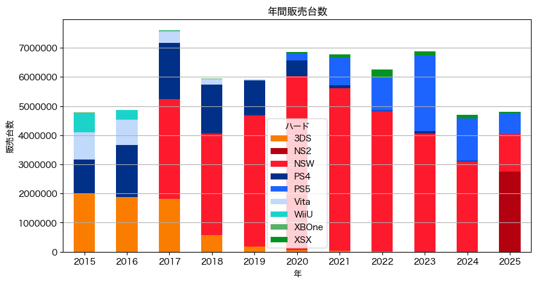

### 年単位のメーカーシェア

2025年 年末商戦でさらなる任天堂シェア上昇が予想されますが、PS5 DE値下げとブラックフライデーセールの効果でどこまで抑えられるか。

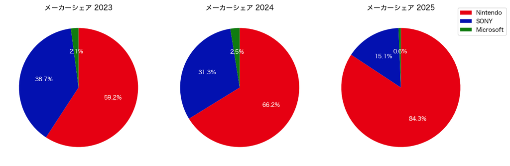